# bioc557_bioinformatics_proteomics

Yuming Shi

2026-11-16

## 1. Set Up

1. set up working directory to your storage by RStudio -> Session -> Set Working Directory -> Choose Directory, build a folder named bioinformatics_proteomics, put data in subfolder bioinformatics_proteomics/data, build a subfolder bioinformatics_proteomics/figure

> **Tip on folders:** *Session → Set Working Directory* only affects the Console. When you click **Knit**, R always uses the folder where this .Rmd file is saved. Easiest setup: save this .Rmd inside `bioinformatics_proteomics/`, so the paths `data/...` and `figure/...` work in both cases. Check where R is looking with `getwd()`.
2. import packages > **Install packages before class.** From CRAN: `install.packages(c("tidyverse", "missForest", "patchwork", "ggrepel", "gprofiler2", "circlize"))`. From Bioconductor: `BiocManager::install(c("limma", "ComplexHeatmap", "preprocessCore"))`. An error like *there is no package called …* means the package is not installed yet. `tidyverse` already contains `readr` and `ggplot2`; loading them again is harmless.

```r
library(readr)
library(tidyverse)
```

```r
library(preprocessCore) #quantile normalization
library(missForest) #random forest imputation
library(ggplot2)
library(ComplexHeatmap)
library(circlize)         # colour scales for ComplexHeatmap
library(patchwork) #combine multiple plots from ggplot2
library(ggrepel) #label dots on volcano plot
library(limma)
library(gprofiler2)
```

## Practice 1

1. import data

```r
#raw data
# read_delim() reads a text file; delim = "\t" means columns are separated by tabs (.tsv)
# data: one row per protein, one column per sample
# meta: one row per sample (group, tissue, replicate, queen, brood)
# Error 'file does not exist'? Check getwd() and that the files are in the data/ folder
data_raw <- read_delim("data/data.tsv", delim = "\t", escape_double = FALSE, trim_ws = TRUE)
#meta data
meta <- read_delim("data/meta.tsv", delim = "\t", escape_double = FALSE, trim_ws = TRUE)
```

## (2) basic information

```r
# read_delim() returns a tibble, and tibbles do not keep row names.
# So we convert to a plain data.frame and move the protein IDs (1st column) into the row names.
#set the first column as row names
data_raw <- as.data.frame(data_raw)
rownames(data_raw) <- data_raw[,1]
data_raw <- data_raw[,-1]

#dimensions: number of protein, number of sample
dim(data_raw)
```

```
## [1] 5391   60
```

```r
#view first 5 rows
head(data_raw)
```

```
##                                                                    QXB04_QLBL_G
## AHM10209.1 actin, partial [Nosema ceranae]                                   NA
## EEQ81461.1 hypothetical protein NCER_102096 [Nosema ceranae BRL01]           NA
## EEQ81765.1 hypothetical protein NCER_101664 [Nosema ceranae BRL01]           NA
## EEQ81834.1 hypothetical protein NCER_101574 [Nosema ceranae BRL01]           NA
## EEQ81943.1 hypothetical protein NCER_101435 [Nosema ceranae BRL01]      9839.71
## EEQ81986.1 hypothetical protein NCER_101380 [Nosema ceranae BRL01]      3915.36
##                                                                    QXB05_QRBR_G
## AHM10209.1 actin, partial [Nosema ceranae]                                   NA
## EEQ81461.1 hypothetical protein NCER_102096 [Nosema ceranae BRL01]           NA
## EEQ81765.1 hypothetical protein NCER_101664 [Nosema ceranae BRL01]           NA
## EEQ81834.1 hypothetical protein NCER_101574 [Nosema ceranae BRL01]           NA
## EEQ81943.1 hypothetical protein NCER_101435 [Nosema ceranae BRL01]    13178.200
## EEQ81986.1 hypothetical protein NCER_101380 [Nosema ceranae BRL01]      357.755
##                                                                    QXB03_QRBR_A
## AHM10209.1 actin, partial [Nosema ceranae]                             44113.70
## EEQ81461.1 hypothetical protein NCER_102096 [Nosema ceranae BRL01]     17761.50
## EEQ81765.1 hypothetical protein NCER_101664 [Nosema ceranae BRL01]     16538.00
## EEQ81834.1 hypothetical protein NCER_101574 [Nosema ceranae BRL01]      5191.85
## EEQ81943.1 hypothetical protein NCER_101435 [Nosema ceranae BRL01]      6137.06
## EEQ81986.1 hypothetical protein NCER_101380 [Nosema ceranae BRL01]      2538.86
##                                                                    QXB05_QLBR_G
## AHM10209.1 actin, partial [Nosema ceranae]                                   NA
## EEQ81461.1 hypothetical protein NCER_102096 [Nosema ceranae BRL01]           NA
## EEQ81765.1 hypothetical protein NCER_101664 [Nosema ceranae BRL01]           NA
## EEQ81834.1 hypothetical protein NCER_101574 [Nosema ceranae BRL01]           NA
## EEQ81943.1 hypothetical protein NCER_101435 [Nosema ceranae BRL01]      13782.4
## EEQ81986.1 hypothetical protein NCER_101380 [Nosema ceranae BRL01]           NA
##                                                                    QXB02_QLBR_H
## AHM10209.1 actin, partial [Nosema ceranae]                            112257.00
## EEQ81461.1 hypothetical protein NCER_102096 [Nosema ceranae BRL01]           NA
## EEQ81765.1 hypothetical protein NCER_101664 [Nosema ceranae BRL01]     23063.20
## EEQ81834.1 hypothetical protein NCER_101574 [Nosema ceranae BRL01]      3500.75
## EEQ81943.1 hypothetical protein NCER_101435 [Nosema ceranae BRL01]     12107.30
## EEQ81986.1 hypothetical protein NCER_101380 [Nosema ceranae BRL01]      1512.82
##                                                                    QXB03_QLBL_A
## AHM10209.1 actin, partial [Nosema ceranae]                            116878.00
## EEQ81461.1 hypothetical protein NCER_102096 [Nosema ceranae BRL01]           NA
## EEQ81765.1 hypothetical protein NCER_101664 [Nosema ceranae BRL01]     47475.50
## EEQ81834.1 hypothetical protein NCER_101574 [Nosema ceranae BRL01]      2526.77
```

[output cut: 365 more lines]

```
## EEQ81986.1 hypothetical protein NCER_101380 [Nosema ceranae BRL01]           NA
##                                                                    QXB02_QLBR_G
## AHM10209.1 actin, partial [Nosema ceranae]                                   NA
## EEQ81461.1 hypothetical protein NCER_102096 [Nosema ceranae BRL01]           NA
## EEQ81765.1 hypothetical protein NCER_101664 [Nosema ceranae BRL01]           NA
## EEQ81834.1 hypothetical protein NCER_101574 [Nosema ceranae BRL01]           NA
## EEQ81943.1 hypothetical protein NCER_101435 [Nosema ceranae BRL01]           NA
## EEQ81986.1 hypothetical protein NCER_101380 [Nosema ceranae BRL01]           NA
##                                                                    QXB06_QRBR_H
## AHM10209.1 actin, partial [Nosema ceranae]                             32119.10
## EEQ81461.1 hypothetical protein NCER_102096 [Nosema ceranae BRL01]           NA
## EEQ81765.1 hypothetical protein NCER_101664 [Nosema ceranae BRL01]     26195.00
## EEQ81834.1 hypothetical protein NCER_101574 [Nosema ceranae BRL01]           NA
## EEQ81943.1 hypothetical protein NCER_101435 [Nosema ceranae BRL01]      7328.53
## EEQ81986.1 hypothetical protein NCER_101380 [Nosema ceranae BRL01]      1408.85
```

```r
# is.na() gives TRUE/FALSE for every cell; sum() counts the TRUEs (TRUE = 1, FALSE = 0)
#count NA
print(paste("number of NA:", sum(is.na(data_raw))))
```

```
## [1] "number of NA: 70153"
```

```r
#NA ratio, round to 4 digits
print(paste("ratio of NA:", round(sum(is.na(data_raw))/(ncol(data_raw)*nrow(data_raw)), 4)))
```

```
## [1] "ratio of NA: 0.2169"
```

```r
#intensity range
range(data_raw, na.rm = TRUE)
```

```
## [1] 2.53149e+00 5.13950e+06
```

```r
#intensity quantile
quantile(data_raw, na.rm = TRUE)
```

```
##          0%         25%         50%         75%        100%
## 2.53149e+00 3.69050e+03 8.38214e+03 2.32524e+04 5.13950e+06
```

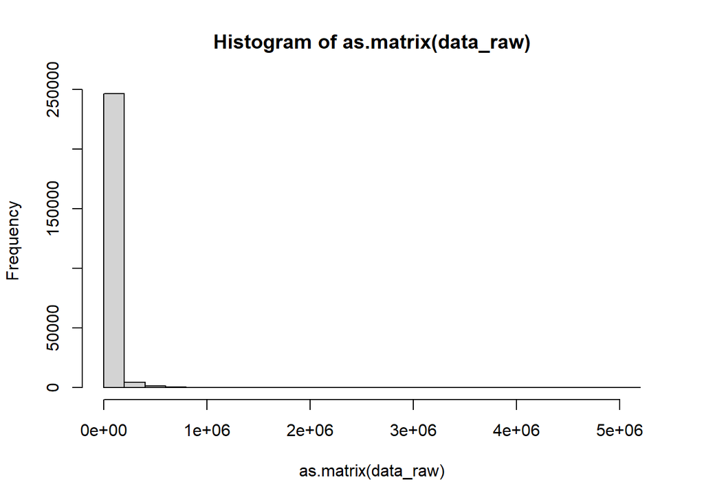

```r
#histogram of intensity distribution
hist(as.matrix(data_raw))
```

```r
# Why log2? Raw intensities span several orders of magnitude and are strongly right-skewed
# (look at the first histogram). After log2 the distribution is roughly symmetric, and
# differences become fold changes: +1 = 2 times higher, -1 = half.
#log 2 transformation
data_log <- log2(data_raw)
#log 2 intensity range
range(data_log, na.rm = TRUE)
```

```
## [1]  1.339987 22.293197
```

```r
#log 2 intensity quantile
quantile(data_log, na.rm = TRUE)
```

```
##        0%       25%       50%       75%      100%
##  1.339987 11.849601 13.033103 14.505092 22.293197
```

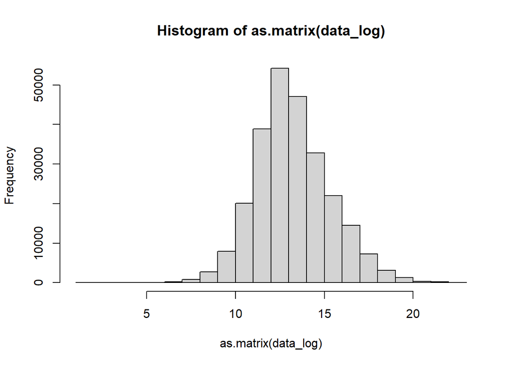

```r
#histogram of log 2 intensity distribution
hist(as.matrix(data_log))
```

```r
# Question: compare the two histograms. Which one looks closer to a bell-shaped (normal) distribution?
# Most statistical tests we use later, including limma, assume roughly normal data.
```

## Practice 2 Filtering, Boxplot, PCA

1. remove contaminants

```r
# Contaminants = proteins that do not come from the sample (keratin from skin and dust,
# trypsin used for digestion, BSA, ...). They are added to the search database so they are not
# mistaken for bee proteins, and are removed before analysis.
#contaminants
contaminants <- read_csv("data/contaminants.tsv")
#search for contaminants
# paste(..., collapse = "|") joins all contaminant IDs into one search pattern "ID1|ID2|ID3" ('|' means OR).
# grep() returns the row numbers whose protein ID matches any of them.
# grep() also matches parts of names, so it is worth checking: rownames(data_log)[cont_pos]
cont_pos <- grep(paste(contaminants$contaminants, collapse = "|"), rownames(data_log))
length(cont_pos) #42 contaminants
```

```
## [1] 42
```

```r
# The minus sign in data_log[-cont_pos, ] removes these rows
data_cf <- data_log[-cont_pos,]
#protein 5391 -> 5349
```

2. keep lowly missed proteins

```r
# rowSums(is.na()) counts the NAs of each protein; dividing by the number of samples gives the fraction missing.
# Proteins missing in most samples carry little information and cannot be imputed reliably.
#calculate protein missing rate
missrate_protein <- rowSums(is.na(data_cf))/ncol(data_cf)
length(which(missrate_protein > 0.7))
```

```
## [1] 446
```

```r
print(paste(length(which(missrate_protein > 0.7)), "protein missing in more than 70% of the samples"))
```

```
## [1] "446 protein missing in more than 70% of the samples"
```

```r
# The cutoff is applied across all 60 samples (all tissues together).
# Example: a protein detected only in head (20/60 samples) is missing in 67% of samples, so it is kept.
# A stricter alternative is to require enough valid values within each tissue or group.
#keep protein missing in less than 70% of the sample
data_m70 <- data_cf[missrate_protein < 0.7,]
```

3. boxplot

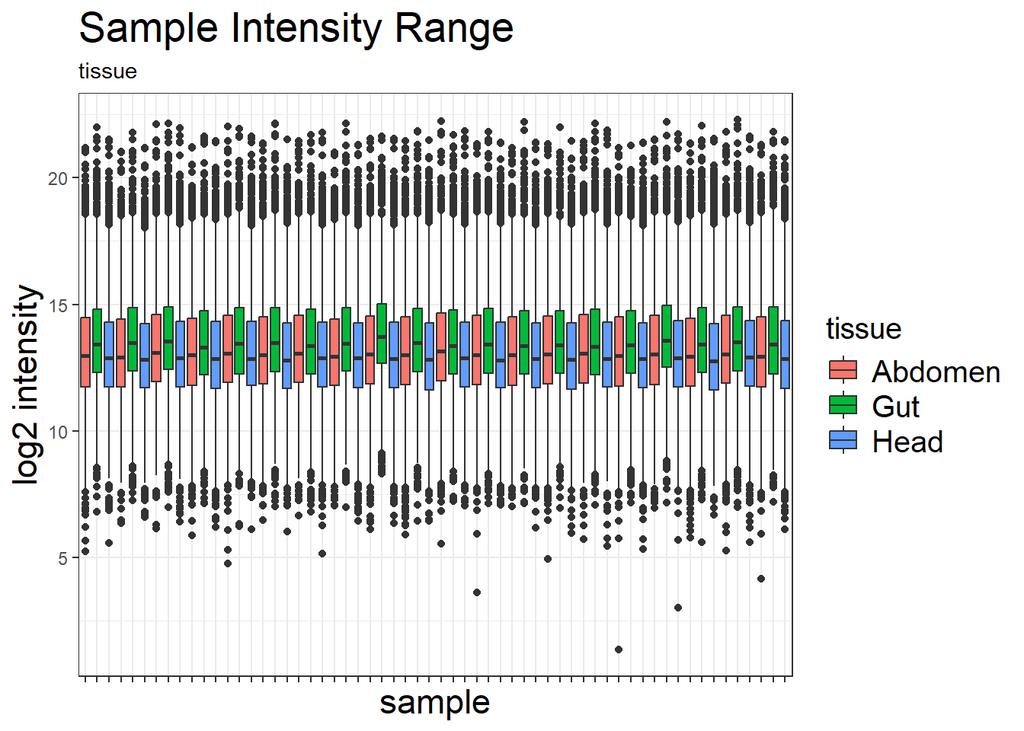

```r
# ggplot needs 'long' format: one row per measurement (protein x sample) instead of one column per sample.
# pivot_longer() does this reshaping. The protein IDs (row names) are dropped here, which is fine for boxplots.
#convert data frame to long format
data_m70_long <- data_m70 %>%
  pivot_longer(cols = 1:ncol(.),
               names_to = "sample",
               values_to = "intensity")

# The tissue is the last letter of the sample name: QXB04_QLBL_G -> G = Gut.
# grep() finds the rows whose sample name contains '_G', '_A' or '_H'.
#get metadata from sample name
#tissue
data_m70_long$tissue <- NA
data_m70_long$tissue[grep("_G", data_m70_long$sample)] <- "Gut"
data_m70_long$tissue[grep("_A", data_m70_long$sample)] <- "Abdomen"
data_m70_long$tissue[grep("_H", data_m70_long$sample)] <- "Head"
#group
# substr(x, 7, 10) takes characters 7 to 10: 'QXB04_QLBL_G' -> 'QLBL'
data_m70_long$group <- substr(data_m70_long$sample, 7, 10)

# How to read a boxplot: thick line = median, box = middle 50% of values,
# whiskers = up to 1.5 x box height, dots = values beyond the whiskers.
# If samples are comparable, their boxes line up.
#tissue labeling
ggplot(data = data_m70_long, aes(x = sample, y = intensity, fill = tissue)) +
  geom_boxplot() +
  labs(title = "Sample Intensity Range",
       subtitle = "tissue",
       x = "sample",
       y = "log2 intensity") +
  theme_bw() +
  theme(axis.text.x = element_blank(), #hide x-axis text
        axis.title = element_text(size = 17), #axis title text size
        legend.text = element_text(size = 15), #legend text size
        legend.title = element_text(size = 15), #legend title text size
        title = element_text(size = 17)) #title text size
```

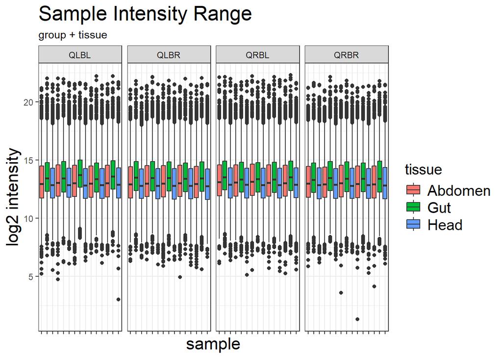

```r
# ggsave(plot = last_plot()) saves the most recently printed ggplot.
# A safer habit: give the plot a name (p <- ggplot(...)) and use ggsave(plot = p).
ggsave("figure/boxplot_tissue.jpeg", plot = last_plot(),
       device = "jpeg", #figure format
       dpi = 300, units = "px",
       width = 2500, height = 1200)
# facet_grid(~ group) splits the plot into one panel per group;
# scales = "free_x" lets each panel show only its own samples.
#facet by group
ggplot(data = data_m70_long, aes(x = sample, y = intensity, fill = tissue)) +
  geom_boxplot() +
  facet_grid(~ group, scales = "free_x", space = "free_x") + #group by group
  labs(title = "Sample Intensity Range",
       subtitle = "group + tissue",
       x = "sample",
       y = "log2 intensity") +
  theme_bw() +
  theme(axis.text.x = element_blank(), #hide x-axis text
        axis.title = element_text(size = 17), #axis title text size
        legend.text = element_text(size = 15), #legend text size
        legend.title = element_text(size = 15), #legend title text size
        title = element_text(size = 17)) #title text size
```

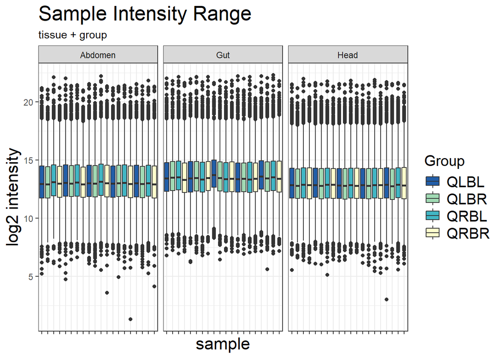

```r
ggsave("figure/boxplot_tissue_group.jpeg", plot = last_plot(),
       device = "jpeg", #figure format
       dpi = 300, units = "px",
       width = 2500, height = 1200)
# Question: within each tissue, do the boxes line up? Between tissues?
# Which of the two matters for our analysis? (We will compare groups within one tissue.)
#facet by tissue
#assign grouping colors
group_cols <- c(QRBR = "#FFFFCC", QLBR = "#A1DAB4",
                QRBL = "#41B6C4", QLBL = "#225EA8")
ggplot(data = data_m70_long, aes(x = sample, y = intensity, fill = group)) +
  geom_boxplot() +
  scale_fill_manual(values = group_cols, name = "Group") +
  # (scale_colour_manual has no effect here because no colour is mapped; it can be ignored)
  scale_colour_manual(values = group_cols, guide = "none") +
  facet_grid(~ tissue, scales = "free_x", space = "free_x") + #group by tissue
  labs(title = "Sample Intensity Range",
       subtitle = "tissue + group",
       x = "sample",
       y = "log2 intensity") +
  theme_bw() +
  theme(axis.text.x = element_blank(), #hide x-axis text
        axis.title = element_text(size = 17), #axis title text size
        legend.text = element_text(size = 15), #legend text size
        legend.title = element_text(size = 15), #legend title text size
        title = element_text(size = 17)) #title text size
```

```r
ggsave("figure/boxplot_group_tissue.jpeg", plot = last_plot(),
       device = "jpeg", #figure format
       dpi = 300, units = "px",
       width = 2500, height = 1200)
```

4. PCA

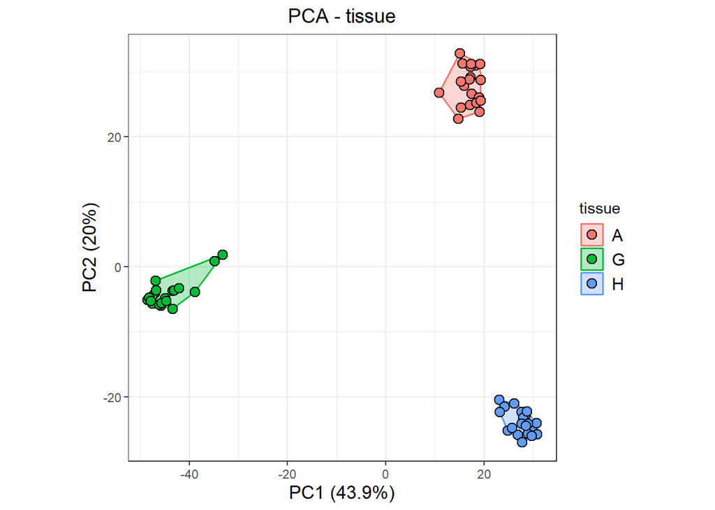

```r
# PCA cannot handle NA values, so we use only proteins quantified in all 60 samples.
#make PCA using complete proteins from the three tissues
data_complete <- data_m70[complete.cases(data_m70),]
#2341 proteins complete

# prcomp() expects samples in rows and variables (proteins) in columns, so we transpose with t().
# center = TRUE subtracts each protein's mean; scale. = TRUE divides by its SD, so every protein
# contributes equally (otherwise the most abundant and variable proteins dominate).
#transpose data frame, calculate PCs
pca <- prcomp(t(data_complete), center = TRUE, scale. = TRUE)

#Eigenvalues = Variances = (standard deviations of the principal components)^2 = pca$sdev^2
#Proportion of variance explained by each component
ve  <- round(100*pca$sdev^2/sum(pca$sdev^2), 1)

# pca$x holds each sample's coordinates (scores) on each PC.
# PC1 = the direction of largest variation among samples; PC2 = the next largest, unrelated to PC1.
#pca$x = PCs
scores <- as.data.frame(pca$x[, 1:2]) %>%
    rownames_to_column("sample") %>% #make row names into a column called sample
    mutate(group  = factor(substr(sample, 7, 10), levels = names(group_cols)), #make a "group" column
           tissue = substr(sample, 12, 12)) #make a "tissue" column

hulls <- scores %>%
  group_by(tissue) %>% #within each tissue
  slice(chull(PC1, PC2)) #returns the row positions of the points on the convex hull that is the smallest convex shape that encloses all the points

#draw pca plot
ggplot(scores, aes(PC1, PC2, fill = tissue)) +
    geom_polygon(data = hulls, aes(colour = tissue), alpha = 0.3, linewidth = 0.6) +
    geom_point(shape = 21, size = 3, colour = "black", stroke = 0.6) +
    labs(title = "PCA - tissue",
         x = paste0("PC1 (", ve[1], "%)"),
         y = paste0("PC2 (", ve[2], "%)")) +
    theme_bw() +
    theme(aspect.ratio = 1,
          plot.title = element_text(hjust = 0.5, size = 14),
          axis.title = element_text(size = 13),
          legend.text = element_text(size = 12))
```

```r
ggsave("figure/pca_tissue.jpeg", plot = last_plot(),
       device = "jpeg", #figure format
       dpi = 300, units = "px",
       width = 1200, height = 1200)

# Question: what separates the samples along PC1, tissue or treatment group?
# What does this tell you about the biggest source of variation in the data?
```

5. (optional) PCA within each tissue

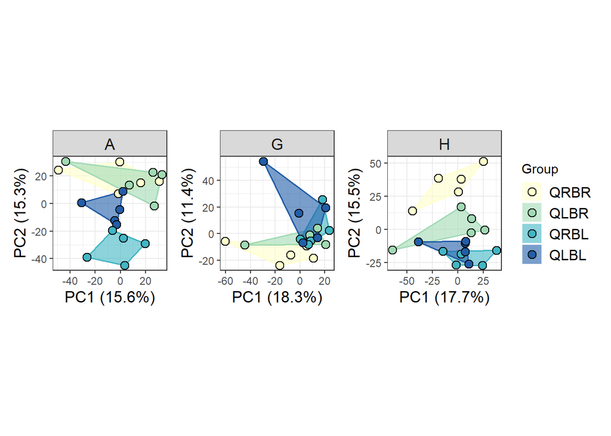

```r
#assign grouping colors
group_cols <- c(QRBR = "#FFFFCC", QLBR = "#A1DAB4",
                QRBL = "#41B6C4", QLBL = "#225EA8")

# A function packs the steps above so we can repeat them for each tissue with one line.
# Each tissue gets its own PCA, so the % variance on the axes differs between panels.
plot_pca_tissue <- function(mat, tissue_name) {
  # keep this tissue's samples and proteins quantified in all of them
  m <- mat[, grepl(paste0("_", substr(tissue_name, 1, 1), "$"), colnames(mat))]
  m <- m[complete.cases(m), ]

  pca <- prcomp(t(m), center = TRUE, scale. = TRUE)
  ve  <- round(100 * pca$sdev^2 / sum(pca$sdev^2), 1)

  scores <- as.data.frame(pca$x[, 1:2]) %>%
    rownames_to_column("sample") %>%
    mutate(group  = factor(substr(sample, 7, 10), levels = names(group_cols)),
           tissue = substr(sample, 12, 12))

  hulls <- scores %>% group_by(group) %>% slice(chull(PC1, PC2))

  ggplot(scores, aes(PC1, PC2, fill = group)) +
    geom_polygon(data = hulls, aes(colour = group), alpha = 0.6, linewidth = 0.6) +
    geom_point(shape = 21, size = 3, colour = "black", stroke = 0.6) +
    scale_fill_manual(values = group_cols, name = "Group") +
    scale_colour_manual(values = group_cols, guide = "none") +
    facet_wrap(~ tissue) +
    labs(x = paste0("PC1 (", ve[1], "%)"),
         y = paste0("PC2 (", ve[2], "%)")) +
    theme_bw() +
    theme(aspect.ratio = 1,
          strip.text = element_text(size = 13),
          axis.title = element_text(size = 13),
          legend.text = element_text(size = 12))
}
# The '|' between plots comes from patchwork: it places plots side by side;
# plot_layout(guides = "collect") merges the three legends into one.
# all three tissues side by side, one shared legend
p_pca_all <- (plot_pca_tissue(data_m70, "A") |
              plot_pca_tissue(data_m70, "G") |
              plot_pca_tissue(data_m70, "H")) +
  plot_layout(guides = "collect")
p_pca_all
```

```r
ggsave("figure/pca_group.jpeg", plot = last_plot(),
       device = "jpeg", #figure format
       dpi = 300, units = "px",
       width = 3600, height = 1200)

# Question: in which tissue do the treatment groups separate best?
# Keep this in mind when you see the number of DEPs later.
```

## Normalization

> **Normalization** removes technical differences between samples, e.g. slightly different amounts of protein loaded. DIA-NN already normalized this data during the search, so here we first **check** whether more normalization is needed, by measuring how far apart the sample medians are within each tissue.

```r
#median offset per tissue
# median_range = highest minus lowest sample median in each tissue (log2 units).
# Reminder: a log2 difference d means a fold change of 2^d, e.g. 2^0.2 = 1.15 = 15% higher.
data_m70_long %>%
  group_by(tissue, sample) %>%
  summarise(med = median(intensity, na.rm = TRUE)) %>%
  summarise(median_range = max(med) - min(med))
```

[output not shown]

```
## # A tibble: 3 × 2
##   tissue  median_range
##   <chr>          <dbl>
## 1 Abdomen        0.242
## 2 Gut            0.408
## 3 Head           0.137
```

```r
# Same calculation, using only proteins quantified in ALL samples of that tissue.
# Why? A sample that detected fewer low-abundance proteins has a higher median simply because
# its weakest proteins are missing, not because more protein was loaded.
#median offset of complete proteins
data_m70 %>%
  rownames_to_column("protein") %>%
  pivot_longer(cols = -protein,
               names_to = "sample",
               values_to = "intensity") %>%
  mutate(tissue = recode(substr(sample, 12, 12), A = "Abdomen", G = "Gut", H = "Head")) %>%
  group_by(tissue) %>%
  filter(!is.na(intensity)) %>%
  group_by(tissue, protein) %>%
  filter(n() == n_distinct(data_m70_long$sample[data_m70_long$tissue == first(tissue)])) %>%
  group_by(tissue, sample) %>% summarise(med = median(intensity), .groups = "drop_last") %>%
  summarise(median_range_complete = max(med) - min(med))
```

```
## # A tibble: 3 × 2
##   tissue  median_range_complete
##   <chr>                   <dbl>
## 1 Abdomen                 0.134
## 2 Gut                     0.219
## 3 Head                    0.102
```

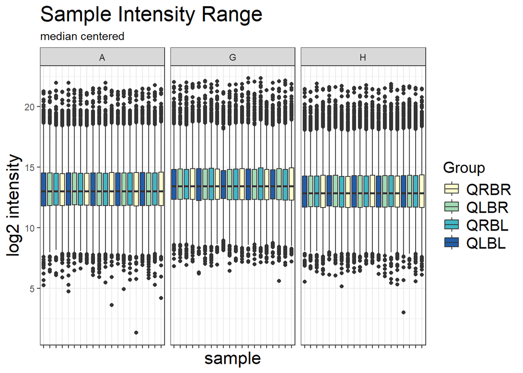

```r
# For demonstration: two normalization methods, applied within each tissue separately
# (tissues have different proteomes, so they should not be forced to look the same).
# - quantile: forces all samples of a tissue to have exactly the same distribution of values.
# - scale: makes the sample medians equal
normalize_by_tissue <- function(mat, method = "quantile") {
  out <- as.matrix(mat)
  for (t in c("A", "G", "H")) {
    idx <- grepl(paste0("_", t, "$"), colnames(out))
    out[, idx] <- limma::normalizeBetweenArrays(out[, idx], method = method)
  }
  out
}

# quantile normalization
data_qn <- normalize_by_tissue(data_m70)
# centered median
data_mc <- normalize_by_tissue(data_m70, method = "scale")

# Compare these boxplots with the ones before normalization: does either method make a meaningful difference?
# In the quantile-normalized plot, look at the lowest dots: why are they identical in every sample?
data_mc %>%
  as.data.frame() %>%
  pivot_longer(cols = 1:ncol(.),
               names_to = "sample",
               values_to = "intensity") %>%
  mutate(group  = factor(substr(sample, 7, 10), levels = names(group_cols)),
           tissue = substr(sample, 12, 12)) %>%
  ggplot(aes(x = sample, y = intensity, fill = group)) +
  geom_boxplot() +
  scale_fill_manual(values = group_cols, name = "Group") +
  scale_colour_manual(values = group_cols, guide = "none") +
  facet_grid(~ tissue, scales = "free_x", space = "free_x") + #group by tissue
  labs(title = "Sample Intensity Range",
       subtitle = "median centered",
       x = "sample",
       y = "log2 intensity") +
  theme_bw() +
  theme(axis.text.x = element_blank(), #hide x-axis text
        axis.title = element_text(size = 17), #axis title text size
        legend.text = element_text(size = 15), #legend text size
        legend.title = element_text(size = 15), #legend title text size
        title = element_text(size = 17)) #title text size
```

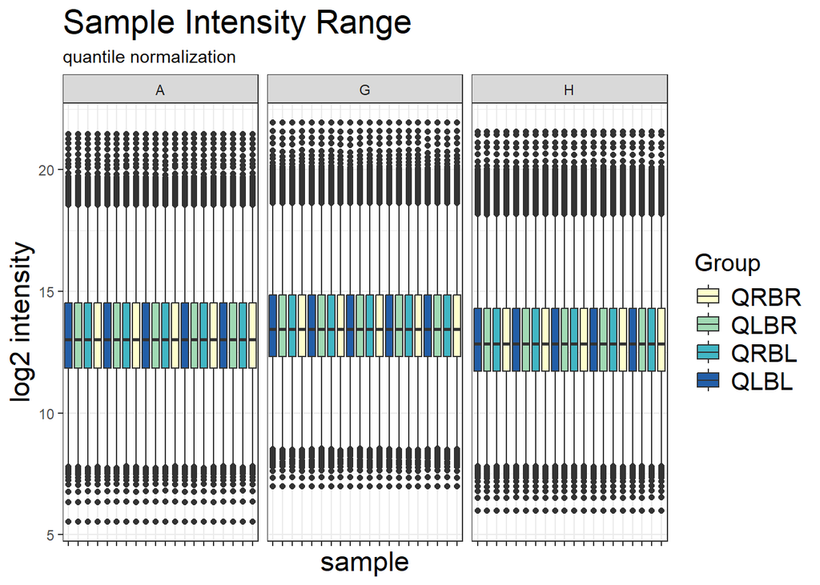

```r
ggsave("figure/boxplot_mc.jpeg", plot = last_plot(),
       device = "jpeg", #figure format
       dpi = 300, units = "px",
       width = 2500, height = 1200)
data_qn %>%
  as.data.frame() %>%
  pivot_longer(cols = 1:ncol(.),
               names_to = "sample",
               values_to = "intensity") %>%
  mutate(group  = factor(substr(sample, 7, 10), levels = names(group_cols)),
           tissue = substr(sample, 12, 12)) %>%
  ggplot(aes(x = sample, y = intensity, fill = group)) +
  geom_boxplot() +
  scale_fill_manual(values = group_cols, name = "Group") +
  scale_colour_manual(values = group_cols, guide = "none") +
  facet_grid(~ tissue, scales = "free_x", space = "free_x") + #group by tissue
  labs(title = "Sample Intensity Range",
       subtitle = "quantile normalization",
       x = "sample",
       y = "log2 intensity") +
  theme_bw() +
  theme(axis.text.x = element_blank(), #hide x-axis text
        axis.title = element_text(size = 17), #axis title text size
        legend.text = element_text(size = 15), #legend text size
        legend.title = element_text(size = 15), #legend title text size
        title = element_text(size = 17)) #title text size
```

```r
ggsave("figure/boxplot_qn.jpeg", plot = last_plot(),
       device = "jpeg", #figure format
       dpi = 300, units = "px",
       width = 2500, height = 1200)
```

> **Conclusion for our data:** using complete proteins, sample medians differ by at most 0.22 log2 (about 16%) within each tissue, which is small. We therefore continue with the DIA-NN normalized data (`data_m70`) without extra normalization.

## Practice 3: Impute missing values and evaluate

**Idea:** We can’t check an imputation against real missing values, because we never know their true value. So we create missing values on purpose: take proteins with no missing values, hide some of the values, impute them, and compare the imputed values with the true ones we hid.

We work in **one tissue (Head)**. Imputation is done within one tissue: a protein missing in gut may simply not exist there, so gut samples should not be used to guess head values.

1. select complete proteins

```r
#select head proteins
# grepl("_H$", ...) is TRUE for sample names that end ($ = end of text) with "_H"
head_mat <- as.matrix(data_m70[, grepl("_H$", colnames(data_m70))])

# proteins quantified in all 20 head samples = our "ground truth"
true_mat <- head_mat[complete.cases(head_mat), ]
dim(true_mat)
```

```
## [1] 3643   20
```

```r
# how much is actually missing in the real head data?
real_na_frac <- mean(is.na(head_mat))
real_na_frac
```

```
## [1] 0.09322938
```

2. Randomly mask 10% values to NA `type = "MCAR"`: every value has the same chance of being hidden (missing completely at random). `type = "MNAR"`: low-intensity values are more likely to be hidden, which is closer to reality

```r
# set.seed() makes the random numbers reproducible, so everyone hides the same values.
# If you rerun only the mask line below (without set.seed), you get a new random mask.
set.seed(42)
# How the function works: runif() draws a random number between 0 and 1 for every value,
# and values whose number is below p are set to NA.
# MNAR: plogis() is an S-shaped curve, so values well below the 25th percentile get p close to 1
# and high values get p close to 0, like an instrument's detection limit.
mask_values <- function(m, frac = 0.1, type = c("MCAR", "MNAR")) {
  type <- match.arg(type)
  if (type == "MCAR") {
    p <- rep(frac, length(m))
  } else {
    # probability of being hidden rises below the 25th percentile
    p <- plogis((quantile(m, 0.25)-m)/0.5)
    p <- pmin(p*frac/mean(p), 1) # rescale, so frac of values are hidden overall
  }
  out <- m
  out[runif(length(m)) < p] <- NA
  out
}

# TRY: change frac (e.g. 0.05, 0.2, real_na_frac) and type ("MCAR" / "MNAR")
na_mat <- mask_values(true_mat, frac = 0.1, type = "MCAR")
mask <- is.na(na_mat) # TRUE where we hid a value
mean(mask) #10.13% masked
```

```
## [1] 0.1013039
```

3. Try three ways of imputation

```r
# 1. Zero: replace every NA with 0
# On the log2 scale, 0 means intensity 1, far below any real value.
# This creates huge fake differences: an example of what NOT to do.
impute_zero <- function(m) {
  m[is.na(m)] <- 0
  m
}

# 2. A random small number from a Gaussian distribution
#  For each sample: draw from Normal(mean - shift * sd, width * sd)
# Assumes values are missing because they were too low to detect (as in Perseus),
# so it fills them with small random values from the low end of each sample's distribution.
# shift = how far below the mean (in SDs); width = how spread out the random values are.
impute_downshift <- function(m, shift = 1.8, width = 0.3) {
  for (j in seq_len(ncol(m))) {
    miss <- is.na(m[, j])
    mu <- mean(m[, j], na.rm = TRUE)
    s <- sd(m[, j], na.rm = TRUE)
    m[miss, j] <- rnorm(sum(miss), mean = mu - shift * s, sd = width * s)
  }
  m
}

# 3. missForest: predicts each sample's missing values from the other samples
#    using random forests (proteins are the observations, samples are the variables)
# Assumes missing values can be predicted from patterns in the other samples
# (works best when values are missing at random).
impute_mf <- function(m) {
  as.matrix(missForest(as.data.frame(m), ntree = 100, verbose = FALSE)$ximp)
}

#takes about 30-60s
imputed <- list(Zero = impute_zero(na_mat),
                Downshift = impute_downshift(na_mat),
                missForest = impute_mf(na_mat))
```

4. Evaluate the performance by NRMSE NRMSE = normalized root mean squared error, computed only on the values we hid:

$$\text{NRMSE} =
\sqrt{\frac{\text{mean}\big((\text{imputed} -
\text{true})^2\big)}{\text{var}(\text{true})}}$$
0 = perfect recovery. Around 1 = no better than guessing the average. Above 1 = worse than guessing the average.

```r
# Only the hidden positions (mask == TRUE) are compared; all other values were not imputed.
nrmse <- function(imputed, truth, mask) {
  sqrt(mean((imputed[mask] - truth[mask])^2) / var(truth[mask]))
}

results <- data.frame(method = names(imputed),
                  NRMSE = map_dbl(imputed, nrmse, truth = true_mat, mask = mask))
results
```

```
##                method     NRMSE
## Zero             Zero 7.3155825
## Downshift   Downshift 2.0940137
## missForest missForest 0.1413182
```

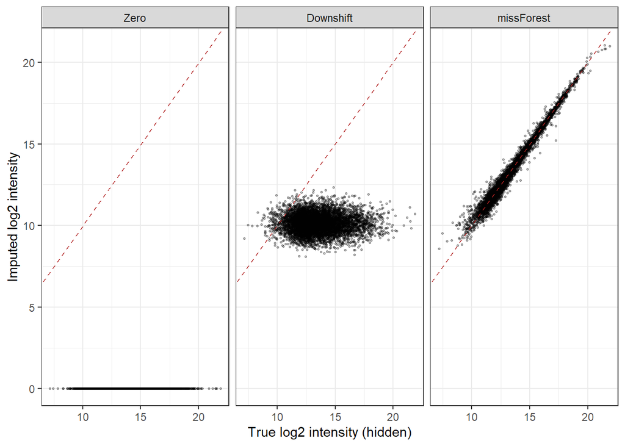

```r
method_levels <- names(imputed)

# imap_dfr() loops over the list 'imputed': .x = the imputed matrix, .y = its name
# (Zero / Downshift / missForest), and stacks the results into one table for plotting.
plot_df <- imap_dfr(imputed, ~ tibble(method = .y,
                                      true = true_mat[mask],
                                      imputed = .x[mask])) %>%
  mutate(method = factor(method, levels = method_levels))

# Points on the red dashed line were recovered perfectly.
# Points below the line were imputed too low, points above too high.
ggplot(plot_df, aes(x = true, y = imputed)) +
  geom_point(alpha = 0.3, size = 0.6) +
  geom_abline(linetype = 2, colour = "firebrick") +   # perfect recovery line
  facet_wrap(~ method) +
  labs(x = "True log2 intensity (hidden)",
       y = "Imputed log2 intensity") +
  theme_bw()
```

```r
ggsave("figure/imputation.jpeg", plot = last_plot(),
       device = "jpeg", #figure format
       dpi = 300, units = "px",
       width = 3600, height = 1200)
```

### Questions

1. Rank the three methods by NRMSE. Look at the scatter plot: *how* is each method wrong (random scatter, or a systematic shift)?
2. Go back to Step 2, change `type = "MNAR"`, and re-run Steps 2–4. Does the ranking change? Which method’s assumption matches MNAR?
3. Missing values in real proteomics data are mostly MNAR. Does our MCAR test make missForest look better or worse than it would on real data?